# Kidney Cox Model Setup

## Load Data

```r
kidney_raw <- read_csv(
  "data/kidrecurr.csv",  # read the kidney recurrence dataset
  show_col_types = FALSE,  # suppress column type messages when knitting
  locale = locale(encoding = "UTF-8")  # safely handle the BOM-tainted header
)

names(kidney_raw)[1] <- "patient"  # clean the first column name

kidney <- kidney_raw %>%
  mutate(
    patient = as.integer(patient),  # patient identifier
    time1 = as.numeric(time1),  # first follow-up time
    infect1 = as.integer(infect1),  # first-interval event flag
    time2 = as.numeric(time2),  # second follow-up time
    infect2 = as.integer(infect2),  # second-interval event flag
    age = as.numeric(age),  # baseline age
    gender = factor(gender, levels = c(0, 1), labels = c("Female", "Male")),  # label sex code
    gn = factor(gn, levels = c(0, 1), labels = c("No", "Yes")),  # glomerulonephritis flag
    an = factor(an, levels = c(0, 1), labels = c("No", "Yes")),  # analgesic nephropathy flag
    pkd = factor(pkd, levels = c(0, 1), labels = c("No", "Yes"))  # polycystic kidney disease flag
  )
```

## EDA

Taking a look at some of the rows of the data.

```r
kidney_preview <- kidney %>%
  slice_head(n = 6)  # preview the first six rows
```

```
# # A tibble: 6 × 10
#   patient time1 infect1 time2 infect2   age gender gn    an    pkd
#     <int> <dbl>   <int> <dbl>   <int> <dbl> <fct>  <fct> <fct> <fct>
# 1       1    16       1     8       1  28   Female No    No    No
# 2       2    13       0    23       1  48   Male   Yes   No    No
# 3       3    22       1    28       1  32   Female No    No    No
# 4       4   318       1   447       1  31.5 Male   No    No    No
# 5       5    30       1    12       1  10   Female No    No    No
# 6       6    24       1   245       1  16.5 Male   No    No    No
```

Plotting the distributions of age and gender.

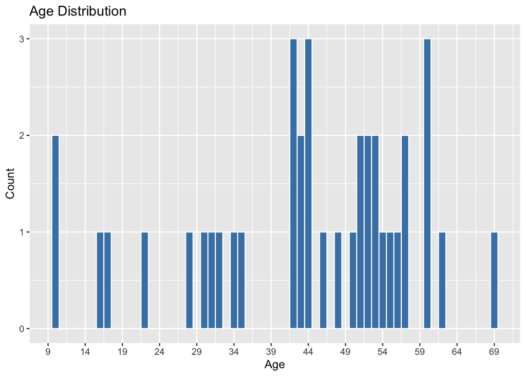

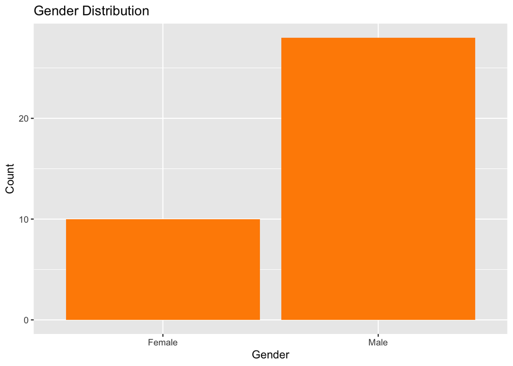

```r
age_plot <- kidney %>%
  ggplot(aes(x = age)) +
  geom_histogram(binwidth = 1, fill = "steelblue", color = "white") +
  scale_x_continuous(
    breaks = seq(9, 75, by = 5)
  ) +
  labs(title = "Age Distribution", x = "Age", y = "Count")

gender_plot <- kidney %>%
  ggplot(aes(x = gender)) +
  geom_bar(fill = "darkorange") +
  labs(title = "Gender Distribution", x = "Gender", y = "Count")
```

```r
kidney_summary <- kidney %>%
  summarise(
    patients = n(),  # total number of patients
    first_events = sum(infect1 == 1, na.rm = TRUE),  # number with a first infection
    censored_first_interval = sum(infect1 == 0, na.rm = TRUE),  # number censored in interval 1
    median_time1 = median(time1, na.rm = TRUE),  # median first follow-up time
    median_age = median(age, na.rm = TRUE)  # median baseline age
  )
```

```
# # A tibble: 1 × 5
#   patients first_events censored_first_interval median_time1 median_age
#      <int>        <int>                   <int>        <dbl>      <dbl>
# 1       38           27                      11         39.5       45.5
```

Understanding the datasets features(https://www.kaggle.com/datasets/hxnzheng/kidrecurr):

The dataset `kidrecurr.csv` contains 38 observations and 10 variables.

[output not shown]

## Building the Cox model

For this notebook, I am using a first event analysis. That means I will use only `time1` and `infect1`, so each patient contributes one follow-up time and one event indicator.

### Step 1: Build the first event modeling dataset

Drop the time2 and infect2 columns

```r
kidney_cox_data <- kidney %>%
  select(patient, time1, infect1, age, gender, gn,an,pkd)
```

Peep the new dataset

```
# Rows: 38
# Columns: 8
# $ patient <int> 1, 2, 3, 4, 5, 6, 7, 8, 9, 10, 11, 12, 13, 14, 15, 16, 17, 18,…
# $ time1   <dbl> 16, 13, 22, 318, 30, 24, 9, 30, 53, 154, 7, 141, 38, 70, 536, …
# $ infect1 <int> 1, 0, 1, 1, 1, 1, 1, 1, 1, 1, 1, 1, 1, 0, 1, 0, 1, 1, 0, 0, 1,…
# $ age     <dbl> 28.0, 48.0, 32.0, 31.5, 10.0, 16.5, 51.0, 55.5, 69.0, 51.5, 44…
# $ gender  <fct> Female, Male, Female, Male, Female, Male, Female, Male, Male, …
# $ gn      <fct> No, Yes, No, No, No, No, Yes, Yes, No, Yes, No, No, No, No, No…
# $ an      <fct> No, No, No, No, No, No, No, No, Yes, No, Yes, No, Yes, Yes, No…
# $ pkd     <fct> No, No, No, No, No, No, No, No, No, No, No, No, No, No, No, No…
```

### Step 2: Create the survival object

This is using a package I found called Survival and its creating a object to say the follow up time and whether the event happened(number without a “+”) or not.

```r
kidney_surv <- Surv(
  time = kidney_cox_data$time1,
  event = kidney_cox_data$infect1
)
```

```
#  [1]  16   13+  22  318   30   24    9   30   53  154    7  141   38   70+ 536
# [16]   4+ 185  114  159+ 108+ 562   24+  66   39   40  113+ 132   34    2   26
# [31]  27    5+ 152  190  119   54+   6+   8+
```

### Step 3: Fit the Cox model

Using the survival package again I fit a Cox model following the documentation.

```r
kidney_cox_model <- coxph(
  kidney_surv ~ age + gender + gn + an + pkd,
  data = kidney_cox_data
)
```

```
# Call:
# coxph(formula = kidney_surv ~ age + gender + gn + an + pkd, data = kidney_cox_data)
#
#   n= 38, number of events= 27
#
#                coef exp(coef) se(coef)      z Pr(>|z|)
# age        -0.00169   0.99831  0.01613 -0.105   0.9165
# genderMale -0.96595   0.38062  0.49847 -1.938   0.0526 .
# gnYes       0.07179   1.07443  0.58530  0.123   0.9024
# anYes       0.81242   2.25334  0.62668  1.296   0.1948
# pkdYes     -2.08352   0.12449  1.19635 -1.742   0.0816 .
# ---
# Signif. codes:  0 '***' 0.001 '**' 0.01 '*' 0.05 '.' 0.1 ' ' 1
#
#            exp(coef) exp(-coef) lower .95 upper .95
# age           0.9983     1.0017   0.96724     1.030
# genderMale    0.3806     2.6273   0.14328     1.011
# gnYes         1.0744     0.9307   0.34117     3.384
# anYes         2.2533     0.4438   0.65977     7.696
# pkdYes        0.1245     8.0327   0.01193     1.299
#
# Concordance= 0.735  (se = 0.05 )
# Likelihood ratio test= 9.38  on 5 df,   p=0.09
# Wald test            = 8.34  on 5 df,   p=0.1
# Score (logrank) test = 8.59  on 5 df,   p=0.1
```

### Step 4: Analysis and Visualization

The expanded Cox model gives a few suggestive patterns, but none of them are strong enough to treat as firm conclusions. Age has a hazard ratio of about `0.998`, which is almost exactly `1`, so age does not appear to change the risk of first infection very much in this model. GN is similar, with a hazard ratio of about `1.07`, which is also close to `1` and does not suggest much of a clear effect.

The more noticeable signals are with gender, AN, and PKD. Male patients have a hazard ratio of about `0.38`, which means their estimated risk of first infection is lower than the reference group. AN has a hazard ratio of about `2.25`, which points toward a higher estimated risk because values above `1` mean the event is happening faster. PKD has a hazard ratio of about `0.12`, which points toward a lower estimated risk because values below `1` mean the event is happening more slowly.

Even so, these results should be treated carefully. The p-values for gender and PKD are close to significance, but they do not quite cross the usual cutoff(of `0.05` from my experience), and the confidence intervals are wide. That means the model is picking up possible signals, but the estimates are still fairly uncertain.

Overall, this model suggests some potentially important differences in infection risk, but with this small sample size can’t really say anything conclusive I dont think.

The forest plot below shows the hazard ratios from the Cox model. Points to the right of `1` suggest higher risk, while points to the left of `1` suggest lower risk. If the confidence interval crosses `1`, the estimate is still uncertain.

```
# `height` was translated to `width`.
```

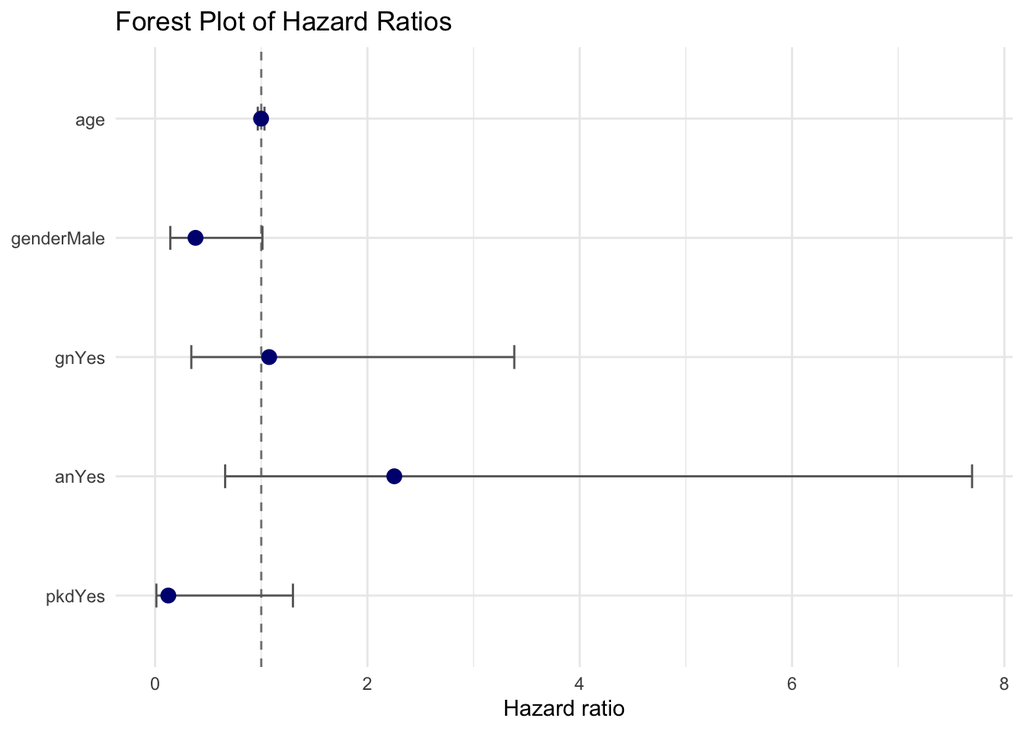

```r
cox_summary <- summary(kidney_cox_model)

forest_data <- tibble(
  term = rownames(cox_summary$coefficients),
  hazard_ratio = cox_summary$coefficients[, "exp(coef)"],
  conf_low = cox_summary$conf.int[, "lower .95"],
  conf_high = cox_summary$conf.int[, "upper .95"]
) %>%
  mutate(term = factor(term, levels = rev(term)))

forest_plot <- ggplot(forest_data, aes(x = hazard_ratio, y = term)) +
  geom_vline(xintercept = 1, linetype = "dashed", color = "gray50") +
  geom_errorbarh(aes(xmin = conf_low, xmax = conf_high), height = 0.2, color = "gray40") +
  geom_point(size = 3, color = "navy") +
  labs(
    title = "Forest Plot of Hazard Ratios",
    x = "Hazard ratio",
    y = NULL
  ) +
  theme_minimal()
# Warning: `geom_errorbarh()` was deprecated in ggplot2 4.0.0.
# ℹ Please use the `orientation` argument of `geom_errorbar()` instead.
# This warning is displayed once per session.
# Call `lifecycle::last_lifecycle_warnings()` to see where this warning was generated.
```